# Vacation Package Project

### By: Kyle Bowen & Will Kittredge

### Objective

A travel agency has asked you and your team to create a machine learning model to help them predict whether or not potential customers will purchase a new vacation package they are offering. As part of this process, the agency would also like to understand the potential customers better to more efficiently market their new package.

### Data Definition

- CustomerID: Unique customer ID
- ProdTaken: Whether the customer has purchased a package or not (0: No, 1: Yes)
- Age: Age of customer
- TypeofContact: How customer was contacted (Company Invited or Self Inquiry)
- CityTier: City tier depends on the development of a city, population, facilities, and living standards. The categories are ordered i.e. Tier 1 > Tier 2 > Tier 3
- DurationOfPitch: Duration of the pitch by a salesperson to the customer
- Occupation: Occupation of customer
- Gender: Gender of customer
- NumberOfPersonVisiting: Total number of people planning to take the trip with the customer
- NumberOfFollowups: Total number of follow-ups has been done by the salesperson after the sales pitch
- ProductPitched: Product pitched by the salesperson
- PreferredPropertyStar: Preferred hotel property rating by customer
- MaritalStatus: Marital status of customer
- NumberOfTrips: Average number of trips in a year by customer
- Passport: The customer has a passport or not (0: No, 1: Yes)
- PitchSatisfactionScore: Sales pitch satisfaction score
- OwnCar: Whether the customers own a car or not (0: No, 1: Yes)
- NumberOfChildrenVisiting: Total number of children with age less than 5 planning to take the trip with the customer
- Designation: Designation of the customer in the current organization
- MonthlyIncome: Gross monthly income of the customer

### Boilerplate

```python
import pandas as pd
import numpy as np


import matplotlib.pyplot as plt
import seaborn as sns

import sklearn.preprocessing
scaler = sklearn.preprocessing.MinMaxScaler()
labelEncoder = sklearn.preprocessing.LabelEncoder()

sns.set(color_codes=True)
%matplotlib inline
```

```python
df = pd.read_csv("vacation_package.csv")
```

### Functions

```python
def ReturnByPurchase(columnparam):
    purchased = df.loc[(df[columnparam].isnull() == False) & (df['ProdTaken'] == 1)]
    nopurchase = df.loc[(df[columnparam].isnull() == False) & (df['ProdTaken'] == 0)]

    print("Purchased Mean: " + str(round(purchased[columnparam].mean(),6)))
    print("Purchased Median: " + str(purchased[columnparam].median()))
    print("Purchased Mode: " + str(purchased[columnparam].mode()))
    print('\n' + "-----------" + '\n')
    print("Unpurchased Mean: " + str(round(nopurchase[columnparam].mean(),6)))
    print("Unpurchased Median: " + str(nopurchase[columnparam].median()))
    print("Unpurchased Mode: " + str(nopurchase[columnparam].mode()))
```

```python
def histogramboxplot(data, feature, figsize=(12,7), kde=True, bins=None):
    """
    Boxplot and histogram combined

    data: dataframe
    feature: dataframe column
    figsize: size of figure (default (12,7))
    kde: whether to show the density curve (default False)
    bins: number of bins for histogram (default None)
    """
    f2, (ax_box2, ax_hist2) = plt.subplots(
        nrows=2,  # Number of rows of the subplot grid= 2
        sharex=True,  # x-axis will be shared among all subplots
        gridspec_kw={"height_ratios": (0.25, 0.75)},
        figsize=figsize,
    )  # creating the 2 subplots

    sns.boxplot(
        data=data, x=feature, ax=ax_box2, showmeans=True, meanprops = dict(marker='D', markeredgecolor='black', markerfacecolor='red')
    )  # boxplot will be created and a star will indicate the mean value of the column

    sns.histplot(
        data=data, x=feature, kde=kde, ax=ax_hist2, bins=bins
    ) if bins else sns.histplot(
        data=data, x=feature, kde=kde, ax=ax_hist2
    )  # For histogram

    ax_hist2.axvline(
        data[feature].mean(), color="red", linestyle="-"
    )  # Add mean to the histogram

    ax_hist2.axvline(
        data[feature].median(), color="black", linestyle="--"
    )  # Add median to the histogram
```

```python
def stackedbarplot(data, predictor, target):
    """
    Print the category counts and plot a stacked bar chart

    data: dataframe
    predictor: independent variable
    target: target variable
    """
    count = data[predictor].nunique()
    sorter = data[target].value_counts().index[-1]
    tab1 = pd.crosstab(data[predictor], data[target], margins=True).sort_values(
        by=sorter, ascending=False
    )
    print(tab1)
    print("-" * 115)
    tab = pd.crosstab(data[predictor], data[target], normalize="index").sort_values(
        by=sorter, ascending=False
    )
    print(tab)
    tab.plot(kind="bar", stacked=True, figsize=(count + 5, 5))
    plt.legend(
        loc="lower left", frameon=False,
    )
    plt.legend(loc="upper left", bbox_to_anchor=(1, 1))
    plt.show()
```

```python
def descviolinbox(Data, tablename):
    """
    Prints the Description of a numeric value and a stacked violin and boxplot

    Data = Dataframe

    value = Target Column

    """
    tablename = str(tablename)

    description = Data[tablename].describe()

    sns.violinplot(data=Data, y=tablename)

    sns.boxplot(data=Data, y=tablename, color="gray")

    return description
```

```python
def bounds(Data, tablename):
    """
    Returns upper and lower bounds for a table, helps us capture outliers

    Data = Dataframe
    tablename = Target Column
    """
    tablename = str(tablename)

    Q1 = Data[tablename].quantile(0.25)
    Q3 = Data[tablename].quantile(0.75)
    IQR = Q3 - Q1
    lowerlim = Q1 - 1.5 * IQR
    upperlim = Q3 + 1.5 * IQR

    print("Q1: " + str(Q1))
    print("Q3: " + str(Q3))
    print("IQR: " + str(IQR))
    print("lower limit: " + str(lowerlim))
    print("upper limit: " + str(upperlim))

    return(lowerlim, upperlim, Q1, Q3)
```

```python
def numericdata(Data, tablename):
    """
    Returns the Mean, Median, Mode, and Range for a dataset

    Data = Dataframe
    tablename = target column
    """
    tablename = str(tablename)

    Q1 = Data[tablename].quantile(0.25)
    Q3 = Data[tablename].quantile(0.75)
    IQR = Q3-Q1
    mean = Data[tablename].mean()
    median = Data[tablename].median()
    mode = Data[tablename].mode()[0]

    mean = round(mean,6)
    median = round(median,6)
    mode = round(mode,6)
    IQR = round(IQR,6)

    print("Mean: " + str(mean))
    print("Median: " + str(median))
    print("Mode: " + str(mode))
    print("Range: " + str(IQR))
```

```python
def labeldisplot(Data, tablename):

        tablename = str(tablename)

        sns.displot(data=Data, x=tablename, kde=True);
        plt.axvline(x=Data[tablename].median(), color = 'black')
        plt.axvline(x=Data[tablename].mean(), color = 'red', ls='--')
```

```python
def labeledbarplot(data, feature, perc=False, n=None):
    """
    Barplot with percentage at the top

    data: dataframe
    feature: dataframe column
    perc: whether to display percentages instead of count (default is False)
    n: displays the top n category levels (default is None, i.e., display all levels)
    """

    total = len(data[feature])  # length of the column
    count = data[feature].nunique()
    if n is None:
        plt.figure(figsize=(count + 1, 5))
    else:
        plt.figure(figsize=(n + 1, 5))

    plt.xticks(rotation=90, fontsize=15)
    ax = sns.countplot(
        data=data,
        x=feature,
        palette="Paired",
        order=data[feature].value_counts().index[:n].sort_values(),
    )

    for p in ax.patches:
        if perc == True:
            label = "{:.1f}%".format(
                100 * p.get_height() / total
            )  # percentage of each class of the category
        else:
            label = p.get_height()  # count of each level of the category

        x = p.get_x() + p.get_width() / 2  # width of the plot
        y = p.get_height()  # height of the plot

        ax.annotate(
            label,
            (x, y),
            ha="center",
            va="center",
            size=12,
            xytext=(0, 5),
            textcoords="offset points",
        )  # annotate the percentage

    plt.show()  # show the plot
```

```python
def stackedbox(data, value, hue):
    """
    data= Dataframe
    Value = Independent variable we want to test
    Hue = Dependent Variable we want to include
    """
    sns.catplot(data= data, x = hue, y = value, kind="box")
```

```python
def minmeanmax(data, independent, dependent):
    """
    Prints the min, mean and max of things grouped by our dependent variable

    data = Dataframe
    independent = The variable we want to do math on
    Dependent = the variable we want to group by
    """

    notpurchased = df.loc[df[dependent] == 0] #Adjust Number of df.Locs for number of variables
    purchased = df.loc[df[dependent] == 1]

    print("Not Purchased Min Mean and Max:" + '\n')
    print(f' Min: {notpurchased[independent].min()}')
    print(f' Mean: {round(notpurchased[independent].mean(), 6)}')
    print(f' Max: {notpurchased[independent].max()}')

    print("\n" + "Purchased Min Mean and Max:" + "\n")
    print(f' Min: {purchased[independent].min()}')
    print(f' Mean: {round(purchased[independent].mean(), 6)}')
    print(f' Max: {purchased[independent].max()}')

    #Add as many print statement blocks as required for the dependent variable, keep this count low
```

# Data Overview

```python
# df.sample(10)
```

|  | CustomerID | ProdTaken | Age | TypeofContact | CityTier | DurationOfPitch | Occupation | Gender | NumberOfPersonVisiting | NumberOfFollowups | ProductPitched | PreferredPropertyStar | MaritalStatus | NumberOfTrips | Passport | PitchSatisfactionScore | OwnCar | NumberOfChildrenVisiting | Designation | MonthlyIncome |
| --- | --- | --- | --- | --- | --- | --- | --- | --- | --- | --- | --- | --- | --- | --- | --- | --- | --- | --- | --- | --- |
| 996 | 200996 | 0 | 27.0 | Self Enquiry | 3 | 16.0 | Small Business | Female | 3 | 4.0 | Deluxe | 3.0 | Divorced | 2.0 | 1 | 3 | 1 | 2.0 | Manager | 20769.0 |
| 100 | 200100 | 1 | 37.0 | Self Enquiry | 2 | 12.0 | Salaried | Male | 3 | 3.0 | Basic | 5.0 | Married | 5.0 | 1 | 2 | 1 | 0.0 | Executive | 17073.0 |
| 4493 | 204493 | 0 | 35.0 | Self Enquiry | 1 | 9.0 | Small Business | Female | 3 | 5.0 | Basic | 5.0 | Unmarried | 3.0 | 0 | 1 | 1 | 1.0 | Executive | 23059.0 |
| 3579 | 203579 | 0 | 47.0 | Self Enquiry | 3 | 7.0 | Salaried | Male | 3 | 2.0 | Super Deluxe | 5.0 | Single | NaN | 0 | 4 | 1 | 2.0 | AVP | 36245.0 |
| 320 | 200320 | 0 | 27.0 | Self Enquiry | 3 | NaN | Salaried | Male | 3 | 3.0 | Deluxe | 3.0 | Single | 2.0 | 1 | 4 | 1 | 2.0 | Manager | NaN |
| 2585 | 202585 | 0 | 46.0 | Self Enquiry | 1 | 36.0 | Small Business | Male | 3 | 4.0 | Basic | 3.0 | Unmarried | 7.0 | 0 | 2 | 1 | 1.0 | Executive | 22130.0 |
| 3409 | 203409 | 0 | 26.0 | Self Enquiry | 1 | 26.0 | Small Business | Male | 4 | 4.0 | Basic | 3.0 | Divorced | 5.0 | 0 | 5 | 1 | 3.0 | Executive | 22347.0 |
| 3718 | 203718 | 0 | 32.0 | Self Enquiry | 3 | 36.0 | Small Business | Female | 4 | 5.0 | Deluxe | 3.0 | Married | 3.0 | 0 | 3 | 1 | 1.0 | Manager | 24146.0 |
| 2039 | 202039 | 0 | 36.0 | Company Invited | 3 | 14.0 | Salaried | Male | 3 | 4.0 | Standard | 5.0 | Unmarried | 2.0 | 0 | 1 | 0 | 0.0 | Senior Manager | 22587.0 |
| 3581 | 203581 | 0 | 23.0 | Company Invited | 1 | 33.0 | Salaried | Female | 3 | 5.0 | Basic | 3.0 | Married | 3.0 | 1 | 3 | 0 | 1.0 | Executive | 21492.0 |

```python
# df.sample(10)
```

|  | CustomerID | ProdTaken | Age | TypeofContact | CityTier | DurationOfPitch | Occupation | Gender | NumberOfPersonVisiting | NumberOfFollowups | ProductPitched | PreferredPropertyStar | MaritalStatus | NumberOfTrips | Passport | PitchSatisfactionScore | OwnCar | NumberOfChildrenVisiting | Designation | MonthlyIncome |
| --- | --- | --- | --- | --- | --- | --- | --- | --- | --- | --- | --- | --- | --- | --- | --- | --- | --- | --- | --- | --- |
| 3602 | 203602 | 0 | 38.0 | Self Enquiry | 1 | 26.0 | Salaried | Male | 3 | 4.0 | Deluxe | 3.0 | Married | 5.0 | 0 | 1 | 0 | 1.0 | Manager | 24446.0 |
| 2235 | 202235 | 0 | 38.0 | Company Invited | 1 | 9.0 | Salaried | Male | 2 | 3.0 | Basic | 3.0 | Married | 4.0 | 0 | 3 | 1 | 0.0 | Executive | 17821.0 |
| 4820 | 204820 | 1 | 35.0 | Self Enquiry | 1 | 14.0 | Salaried | Male | 4 | 4.0 | Deluxe | 3.0 | Married | 3.0 | 0 | 3 | 0 | 1.0 | Manager | 21263.0 |
| 2864 | 202864 | 0 | 30.0 | Self Enquiry | 1 | 10.0 | Small Business | Male | 4 | 5.0 | Standard | 3.0 | Divorced | 3.0 | 0 | 2 | 1 | 3.0 | Senior Manager | 30613.0 |
| 1577 | 201577 | 1 | 25.0 | Self Enquiry | 3 | 11.0 | Small Business | Male | 2 | 4.0 | Deluxe | 3.0 | Single | 2.0 | 1 | 3 | 0 | 1.0 | Manager | 20744.0 |
| 3342 | 203342 | 0 | 44.0 | Self Enquiry | 1 | 10.0 | Salaried | Male | 4 | 6.0 | King | NaN | Divorced | 5.0 | 0 | 5 | 1 | 3.0 | VP | 38418.0 |
| 1303 | 201303 | 0 | 47.0 | Self Enquiry | 1 | 10.0 | Salaried | Female | 3 | 4.0 | Standard | 4.0 | Married | 1.0 | 1 | 4 | 1 | 2.0 | Senior Manager | 25333.0 |
| 666 | 200666 | 1 | NaN | Self Enquiry | 1 | 9.0 | Salaried | Female | 2 | 3.0 | Deluxe | 3.0 | Divorced | 1.0 | 1 | 5 | 1 | 1.0 | Manager | NaN |
| 1129 | 201129 | 0 | 42.0 | Self Enquiry | 1 | 15.0 | Salaried | Male | 3 | 4.0 | King | 3.0 | Single | 1.0 | 0 | 1 | 1 | 1.0 | VP | 34613.0 |
| 1232 | 201232 | 0 | 35.0 | Self Enquiry | 1 | 33.0 | Salaried | Male | 2 | 3.0 | Deluxe | 3.0 | Married | 3.0 | 0 | 5 | 0 | 1.0 | Manager | 21883.0 |

##### Observation

Null values appear to be represented as NaN

```python
df.shape
```

```
(4888, 20)
```

##### Observation

There appears to be 20 columns and 4888 rows

```python
df.info()
```

```
<class 'pandas.core.frame.DataFrame'>
RangeIndex: 4888 entries, 0 to 4887
Data columns (total 20 columns):
 #   Column                    Non-Null Count  Dtype
---  ------                    --------------  -----
 0   CustomerID                4888 non-null   int64
 1   ProdTaken                 4888 non-null   int64
 2   Age                       4662 non-null   float64
 3   TypeofContact             4863 non-null   object
 4   CityTier                  4888 non-null   int64
 5   DurationOfPitch           4637 non-null   float64
 6   Occupation                4888 non-null   object
 7   Gender                    4888 non-null   object
 8   NumberOfPersonVisiting    4888 non-null   int64
 9   NumberOfFollowups         4843 non-null   float64
 10  ProductPitched            4888 non-null   object
 11  PreferredPropertyStar     4862 non-null   float64
 12  MaritalStatus             4888 non-null   object
 13  NumberOfTrips             4748 non-null   float64
 14  Passport                  4888 non-null   int64
 15  PitchSatisfactionScore    4888 non-null   int64
 16  OwnCar                    4888 non-null   int64
 17  NumberOfChildrenVisiting  4822 non-null   float64
 18  Designation               4888 non-null   object
 19  MonthlyIncome             4655 non-null   float64
dtypes: float64(7), int64(7), object(6)
memory usage: 763.9+ KB
```

##### Observation

Our data appears to all be floats, integers, and objects, and they all make sense for where they are. There appear to be a few null values in our dataset

```python
df.isnull().sum()
```

```
CustomerID                    0
ProdTaken                     0
Age                         226
TypeofContact                25
CityTier                      0
DurationOfPitch             251
Occupation                    0
Gender                        0
NumberOfPersonVisiting        0
NumberOfFollowups            45
ProductPitched                0
PreferredPropertyStar        26
MaritalStatus                 0
NumberOfTrips               140
Passport                      0
PitchSatisfactionScore        0
OwnCar                        0
NumberOfChildrenVisiting     66
Designation                   0
MonthlyIncome               233
dtype: int64
```

##### Observation

we have welll over 200 empty rows in three columns, one column with over 100 and 4 more with less than 100, these will need to be handled

```python
df.duplicated().sum()
```

```
0
```

##### Observation

There are no duplicate rows in our dataset

### Exploring Numeric Data

```python
df.describe().T
```

|  | count | mean | std | min | 25% | 50% | 75% | max |
| --- | --- | --- | --- | --- | --- | --- | --- | --- |
| CustomerID | 4888.0 | 202443.500000 | 1411.188388 | 200000.0 | 201221.75 | 202443.5 | 203665.25 | 204887.0 |
| ProdTaken | 4888.0 | 0.188216 | 0.390925 | 0.0 | 0.00 | 0.0 | 0.00 | 1.0 |
| Age | 4662.0 | 37.622265 | 9.316387 | 18.0 | 31.00 | 36.0 | 44.00 | 61.0 |
| CityTier | 4888.0 | 1.654255 | 0.916583 | 1.0 | 1.00 | 1.0 | 3.00 | 3.0 |
| DurationOfPitch | 4637.0 | 15.490835 | 8.519643 | 5.0 | 9.00 | 13.0 | 20.00 | 127.0 |
| NumberOfPersonVisiting | 4888.0 | 2.905074 | 0.724891 | 1.0 | 2.00 | 3.0 | 3.00 | 5.0 |
| NumberOfFollowups | 4843.0 | 3.708445 | 1.002509 | 1.0 | 3.00 | 4.0 | 4.00 | 6.0 |
| PreferredPropertyStar | 4862.0 | 3.581037 | 0.798009 | 3.0 | 3.00 | 3.0 | 4.00 | 5.0 |
| NumberOfTrips | 4748.0 | 3.236521 | 1.849019 | 1.0 | 2.00 | 3.0 | 4.00 | 22.0 |
| Passport | 4888.0 | 0.290917 | 0.454232 | 0.0 | 0.00 | 0.0 | 1.00 | 1.0 |
| PitchSatisfactionScore | 4888.0 | 3.078151 | 1.365792 | 1.0 | 2.00 | 3.0 | 4.00 | 5.0 |
| OwnCar | 4888.0 | 0.620295 | 0.485363 | 0.0 | 0.00 | 1.0 | 1.00 | 1.0 |
| NumberOfChildrenVisiting | 4822.0 | 1.187267 | 0.857861 | 0.0 | 1.00 | 1.0 | 2.00 | 3.0 |
| MonthlyIncome | 4655.0 | 23619.853491 | 5380.698361 | 1000.0 | 20346.00 | 22347.0 | 25571.00 | 98678.0 |

```python
# df.mode()
```

|  | CustomerID | ProdTaken | Age | TypeofContact | CityTier | DurationOfPitch | Occupation | Gender | NumberOfPersonVisiting | NumberOfFollowups | ProductPitched | PreferredPropertyStar | MaritalStatus | NumberOfTrips | Passport | PitchSatisfactionScore | OwnCar | NumberOfChildrenVisiting | Designation | MonthlyIncome |
| --- | --- | --- | --- | --- | --- | --- | --- | --- | --- | --- | --- | --- | --- | --- | --- | --- | --- | --- | --- | --- |
| 0 | 200000 | 0.0 | 35.0 | Self Enquiry | 1.0 | 9.0 | Salaried | Male | 3.0 | 4.0 | Basic | 3.0 | Married | 2.0 | 0.0 | 3.0 | 1.0 | 1.0 | Executive | 17342.0 |
| 1 | 200001 | NaN | NaN | NaN | NaN | NaN | NaN | NaN | NaN | NaN | NaN | NaN | NaN | NaN | NaN | NaN | NaN | NaN | NaN | 20855.0 |
| 2 | 200002 | NaN | NaN | NaN | NaN | NaN | NaN | NaN | NaN | NaN | NaN | NaN | NaN | NaN | NaN | NaN | NaN | NaN | NaN | 21020.0 |
| 3 | 200003 | NaN | NaN | NaN | NaN | NaN | NaN | NaN | NaN | NaN | NaN | NaN | NaN | NaN | NaN | NaN | NaN | NaN | NaN | 21288.0 |
| 4 | 200004 | NaN | NaN | NaN | NaN | NaN | NaN | NaN | NaN | NaN | NaN | NaN | NaN | NaN | NaN | NaN | NaN | NaN | NaN | NaN |
| ... | ... | ... | ... | ... | ... | ... | ... | ... | ... | ... | ... | ... | ... | ... | ... | ... | ... | ... | ... | ... |
| 4883 | 204883 | NaN | NaN | NaN | NaN | NaN | NaN | NaN | NaN | NaN | NaN | NaN | NaN | NaN | NaN | NaN | NaN | NaN | NaN | NaN |
| 4884 | 204884 | NaN | NaN | NaN | NaN | NaN | NaN | NaN | NaN | NaN | NaN | NaN | NaN | NaN | NaN | NaN | NaN | NaN | NaN | NaN |
| 4885 | 204885 | NaN | NaN | NaN | NaN | NaN | NaN | NaN | NaN | NaN | NaN | NaN | NaN | NaN | NaN | NaN | NaN | NaN | NaN | NaN |
| 4886 | 204886 | NaN | NaN | NaN | NaN | NaN | NaN | NaN | NaN | NaN | NaN | NaN | NaN | NaN | NaN | NaN | NaN | NaN | NaN | NaN |
| 4887 | 204887 | NaN | NaN | NaN | NaN | NaN | NaN | NaN | NaN | NaN | NaN | NaN | NaN | NaN | NaN | NaN | NaN | NaN | NaN | NaN |

4888 rows × 20 columns

##### Observations

- Most people did not purchase a package
- Ages range from 18 to 61, with the middle being in the mid 30s
- City Tier ranges from 1-3, with most people being in a Tier 1 city
- Pitches ranged from 5 minutes to 2 hours with most being 13-15 minutes
- Only 1-5 people visited a destination, with most common number of people visiting being three
- There were usually 4 followups
- The most frequent product pitched was the basic package
- Preferred Properties ranged from 3-5 stars, with most being 3 stars
- Most individuals wer married
- There were between 1 to 22 trips taken annually, with the middle being 3, and most people taking 2.
- Most people did not have a passport
- Pitch Satisfaction Scores hovered around 3
- Most Individuals owned a car
- On average one child went with each person
- The most common designation was executive
- The average monthly salary hovered between 22 and 23k

```python
# df.corr()
```

|  | CustomerID | ProdTaken | Age | CityTier | DurationOfPitch | NumberOfPersonVisiting | NumberOfFollowups | PreferredPropertyStar | NumberOfTrips | Passport | PitchSatisfactionScore | OwnCar | NumberOfChildrenVisiting | MonthlyIncome |
| --- | --- | --- | --- | --- | --- | --- | --- | --- | --- | --- | --- | --- | --- | --- |
| CustomerID | 1.000000 | 0.056506 | 0.032127 | 0.012975 | 0.064298 | 0.604013 | 0.427539 | 0.010553 | 0.224848 | 0.007974 | -0.035847 | 0.003805 | 0.511763 | 0.276833 |
| ProdTaken | 0.056506 | 1.000000 | -0.147254 | 0.086852 | 0.078257 | 0.009627 | 0.112171 | 0.099577 | 0.018898 | 0.260844 | 0.051394 | -0.011508 | 0.007421 | -0.130585 |
| Age | 0.032127 | -0.147254 | 1.000000 | -0.015625 | -0.012063 | 0.011621 | -0.002577 | -0.010474 | 0.184905 | 0.033399 | 0.018510 | 0.048654 | 0.007370 | 0.464869 |
| CityTier | 0.012975 | 0.086852 | -0.015625 | 1.000000 | 0.022703 | -0.001671 | 0.023652 | -0.009164 | -0.029709 | 0.001793 | -0.042160 | 0.003817 | 0.000672 | 0.051817 |
| DurationOfPitch | 0.064298 | 0.078257 | -0.012063 | 0.022703 | 1.000000 | 0.065141 | 0.009434 | -0.006637 | 0.009715 | 0.033034 | -0.002880 | -0.001626 | 0.031408 | -0.006252 |
| NumberOfPersonVisiting | 0.604013 | 0.009627 | 0.011621 | -0.001671 | 0.065141 | 1.000000 | 0.328569 | 0.033867 | 0.195223 | 0.011177 | -0.019581 | 0.010362 | 0.610621 | 0.195134 |
| NumberOfFollowups | 0.427539 | 0.112171 | -0.002577 | 0.023652 | 0.009434 | 0.328569 | 1.000000 | -0.024176 | 0.139517 | 0.004970 | 0.004054 | 0.012112 | 0.286425 | 0.176503 |
| PreferredPropertyStar | 0.010553 | 0.099577 | -0.010474 | -0.009164 | -0.006637 | 0.033867 | -0.024176 | 1.000000 | 0.012115 | 0.001040 | -0.022701 | 0.015742 | 0.035798 | 0.014289 |
| NumberOfTrips | 0.224848 | 0.018898 | 0.184905 | -0.029709 | 0.009715 | 0.195223 | 0.139517 | 0.012115 | 1.000000 | 0.012949 | -0.004378 | -0.011825 | 0.168795 | 0.139105 |
| Passport | 0.007974 | 0.260844 | 0.033399 | 0.001793 | 0.033034 | 0.011177 | 0.004970 | 0.001040 | 0.012949 | 1.000000 | 0.002926 | -0.022330 | 0.020264 | 0.002545 |
| PitchSatisfactionScore | -0.035847 | 0.051394 | 0.018510 | -0.042160 | -0.002880 | -0.019581 | 0.004054 | -0.022701 | -0.004378 | 0.002926 | 1.000000 | 0.068850 | 0.000878 | 0.030421 |
| OwnCar | 0.003805 | -0.011508 | 0.048654 | 0.003817 | -0.001626 | 0.010362 | 0.012112 | 0.015742 | -0.011825 | -0.022330 | 0.068850 | 1.000000 | 0.026572 | 0.080262 |
| NumberOfChildrenVisiting | 0.511763 | 0.007421 | 0.007370 | 0.000672 | 0.031408 | 0.610621 | 0.286425 | 0.035798 | 0.168795 | 0.020264 | 0.000878 | 0.026572 | 1.000000 | 0.201643 |
| MonthlyIncome | 0.276833 | -0.130585 | 0.464869 | 0.051817 | -0.006252 | 0.195134 | 0.176503 | 0.014289 | 0.139105 | 0.002545 | 0.030421 | 0.080262 | 0.201643 | 1.000000 |

### Checking for Odd Categorical Data

```python
df.nunique()
```

```
CustomerID                  4888
ProdTaken                      2
Age                           44
TypeofContact                  2
CityTier                       3
DurationOfPitch               34
Occupation                     4
Gender                         3
NumberOfPersonVisiting         5
NumberOfFollowups              6
ProductPitched                 5
PreferredPropertyStar          3
MaritalStatus                  4
NumberOfTrips                 12
Passport                       2
PitchSatisfactionScore         5
OwnCar                         2
NumberOfChildrenVisiting       4
Designation                    5
MonthlyIncome               2475
dtype: int64
```

##### Observations

There are some odd things here, like three unique genders and four unique marital statuses.

```python
df['Gender'].value_counts()
```

```
Male       2916
Female     1817
Fe Male     155
Name: Gender, dtype: int64
```

There are 155 incorrect labels for the "Female" Category

```python
df['MaritalStatus'].value_counts()
```

```
Married      2340
Divorced      950
Single        916
Unmarried     682
Name: MaritalStatus, dtype: int64
```

There isn't anything wrong with this category, but it might be possible to lump them int married and unmarried if we want to down the line

### Removing Unnecessary Column(s)

We know each value is unique, but we do not need an ID, since we do not desire to keep track of individual customers in our dataset, rather we want to be able to predict based on values that have bearing besides autoincrements

```python
df = df.drop(['CustomerID'], axis = 1)
```

```python
# df.head(5)
```

|  | ProdTaken | Age | TypeofContact | CityTier | DurationOfPitch | Occupation | Gender | NumberOfPersonVisiting | NumberOfFollowups | ProductPitched | PreferredPropertyStar | MaritalStatus | NumberOfTrips | Passport | PitchSatisfactionScore | OwnCar | NumberOfChildrenVisiting | Designation | MonthlyIncome |
| --- | --- | --- | --- | --- | --- | --- | --- | --- | --- | --- | --- | --- | --- | --- | --- | --- | --- | --- | --- |
| 0 | 1 | 41.0 | Self Enquiry | 3 | 6.0 | Salaried | Female | 3 | 3.0 | Deluxe | 3.0 | Single | 1.0 | 1 | 2 | 1 | 0.0 | Manager | 20993.0 |
| 1 | 0 | 49.0 | Company Invited | 1 | 14.0 | Salaried | Male | 3 | 4.0 | Deluxe | 4.0 | Divorced | 2.0 | 0 | 3 | 1 | 2.0 | Manager | 20130.0 |
| 2 | 1 | 37.0 | Self Enquiry | 1 | 8.0 | Free Lancer | Male | 3 | 4.0 | Basic | 3.0 | Single | 7.0 | 1 | 3 | 0 | 0.0 | Executive | 17090.0 |
| 3 | 0 | 33.0 | Company Invited | 1 | 9.0 | Salaried | Female | 2 | 3.0 | Basic | 3.0 | Divorced | 2.0 | 1 | 5 | 1 | 1.0 | Executive | 17909.0 |
| 4 | 0 | NaN | Self Enquiry | 1 | 8.0 | Small Business | Male | 2 | 3.0 | Basic | 4.0 | Divorced | 1.0 | 0 | 5 | 1 | 0.0 | Executive | 18468.0 |

# Data Preprocessing

## Handling Null values

```python
df.isnull().sum()
```

```
ProdTaken                     0
Age                         226
TypeofContact                25
CityTier                      0
DurationOfPitch             251
Occupation                    0
Gender                        0
NumberOfPersonVisiting        0
NumberOfFollowups            45
ProductPitched                0
PreferredPropertyStar        26
MaritalStatus                 0
NumberOfTrips               140
Passport                      0
PitchSatisfactionScore        0
OwnCar                        0
NumberOfChildrenVisiting     66
Designation                   0
MonthlyIncome               233
dtype: int64
```

### Age

```python
df.Age.isna().sum()
```

```
226
```

```python
df.Age.describe().T
```

```
count    4662.000000
mean       37.622265
std         9.316387
min        18.000000
25%        31.000000
50%        36.000000
75%        44.000000
max        61.000000
Name: Age, dtype: float64
```

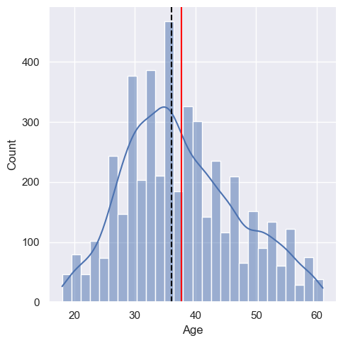

```python
sns.displot(df['Age'], kde = True)
plt.axvline(x = df.Age.median(), color = 'black', ls='--')
plt.axvline(x = df.Age.mean(), color = 'red')
```

##### Observations

The data is skewed right, and given that it likely has a bearing on the dependent variable, and a difference depending on whether or not they purchased, imputing the median based on whether or not they purchased ticket seems like a smart idea.

##### Finding the values

```python
ReturnByPurchase('Age')
```

```
Purchased Mean: 34.770548
Purchased Median: 33.0
Purchased Mode: 0    29.0
Name: Age, dtype: float64

-----------

Unpurchased Mean: 38.282092
Unpurchased Median: 37.0
Unpurchased Mode: 0    36.0
Name: Age, dtype: float64
```

##### Setting the Values

```python
df.loc[(df['Age'].isnull() == True) & (df['ProdTaken'] == 1), ['Age']] = 33
df.loc[(df['Age'].isnull() == True) & (df['ProdTaken'] == 0),['Age']] = 37
```

#### Examining Changes

```python
df.Age.isnull().sum()
```

```
0
```

```python
df.Age.describe().T
```

```
count    4888.000000
mean       37.557488
std         9.109545
min        18.000000
25%        31.000000
50%        37.000000
75%        43.000000
max        61.000000
Name: Age, dtype: float64
```

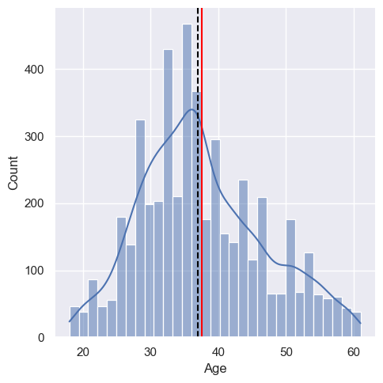

```python
sns.displot(df['Age'], kde = True)
plt.axvline(x = df.Age.median(), color = 'black', ls='--')
plt.axvline(x = df.Age.mean(), color = 'red')
```

The median and the mean appear to have been brought closer together in this dataset due to the imputing we just did, but overall the datas structure has not changed much

### Type of Contact

```python
df.TypeofContact.isna().sum()
```

```
25
```

```python
# df[df['TypeofContact'].isnull()]
```

|  | ProdTaken | Age | TypeofContact | CityTier | DurationOfPitch | Occupation | Gender | NumberOfPersonVisiting | NumberOfFollowups | ProductPitched | PreferredPropertyStar | MaritalStatus | NumberOfTrips | Passport | PitchSatisfactionScore | OwnCar | NumberOfChildrenVisiting | Designation | MonthlyIncome |
| --- | --- | --- | --- | --- | --- | --- | --- | --- | --- | --- | --- | --- | --- | --- | --- | --- | --- | --- | --- |
| 224 | 0 | 31.0 | NaN | 1 | NaN | Small Business | Male | 2 | 5.0 | Deluxe | 3.0 | Divorced | 1.0 | 0 | 3 | 1 | 0.0 | Manager | NaN |
| 571 | 0 | 26.0 | NaN | 1 | NaN | Salaried | Female | 3 | 5.0 | Basic | 3.0 | Married | 4.0 | 0 | 4 | 1 | 2.0 | Executive | NaN |
| 572 | 0 | 29.0 | NaN | 1 | NaN | Small Business | Female | 3 | 3.0 | Deluxe | 3.0 | Divorced | 5.0 | 0 | 2 | 1 | 0.0 | Manager | NaN |
| 576 | 0 | 27.0 | NaN | 3 | NaN | Small Business | Male | 2 | 3.0 | Deluxe | 3.0 | Divorced | 1.0 | 0 | 3 | 0 | 1.0 | Manager | NaN |
| 579 | 0 | 34.0 | NaN | 1 | NaN | Small Business | Female | 2 | 4.0 | Basic | 5.0 | Single | 2.0 | 0 | 2 | 1 | 1.0 | Executive | NaN |
| 598 | 1 | 28.0 | NaN | 1 | NaN | Small Business | Male | 2 | 3.0 | Basic | 3.0 | Single | 7.0 | 0 | 3 | 0 | 0.0 | Executive | NaN |
| 622 | 0 | 32.0 | NaN | 3 | NaN | Salaried | Male | 3 | 3.0 | Deluxe | 3.0 | Married | 3.0 | 0 | 2 | 0 | 0.0 | Manager | NaN |
| 724 | 0 | 24.0 | NaN | 1 | NaN | Small Business | Female | 2 | 4.0 | Deluxe | 3.0 | Married | 2.0 | 0 | 3 | 1 | 1.0 | Manager | NaN |
| 843 | 0 | 26.0 | NaN | 1 | NaN | Small Business | Male | 2 | 1.0 | Basic | 3.0 | Divorced | 2.0 | 0 | 5 | 1 | 1.0 | Executive | NaN |
| 1021 | 1 | 25.0 | NaN | 3 | NaN | Salaried | Male | 3 | 4.0 | Basic | 5.0 | Divorced | 4.0 | 0 | 1 | 1 | 0.0 | Executive | NaN |
| 1047 | 0 | 33.0 | NaN | 3 | NaN | Small Business | Male | 2 | 3.0 | Deluxe | 5.0 | Divorced | 1.0 | 0 | 3 | 0 | 0.0 | Manager | NaN |
| 1143 | 0 | 45.0 | NaN | 3 | NaN | Small Business | Male | 2 | 4.0 | Deluxe | 5.0 | Married | 2.0 | 0 | 3 | 0 | 0.0 | Manager | NaN |
| 1182 | 0 | 36.0 | NaN | 1 | NaN | Small Business | Female | 2 | 4.0 | Deluxe | 3.0 | Married | 1.0 | 0 | 5 | 1 | 1.0 | Manager | NaN |
| 1217 | 0 | 24.0 | NaN | 1 | NaN | Small Business | Male | 3 | 1.0 | Basic | 3.0 | Married | 2.0 | 0 | 1 | 0 | 0.0 | Executive | NaN |
| 1356 | 0 | 41.0 | NaN | 3 | NaN | Small Business | Female | 2 | 3.0 | Deluxe | 4.0 | Married | 6.0 | 0 | 3 | 1 | 1.0 | Manager | NaN |
| 1469 | 0 | 34.0 | NaN | 1 | NaN | Small Business | Male | 2 | 1.0 | Deluxe | 3.0 | Married | 3.0 | 0 | 3 | 0 | 1.0 | Manager | NaN |
| 1694 | 0 | 31.0 | NaN | 1 | NaN | Small Business | Male | 2 | 5.0 | Deluxe | 3.0 | Married | 1.0 | 0 | 3 | 0 | 0.0 | Manager | NaN |
| 2041 | 0 | 26.0 | NaN | 1 | NaN | Salaried | Female | 3 | 5.0 | Basic | 3.0 | Married | 4.0 | 0 | 4 | 1 | 0.0 | Executive | NaN |
| 2042 | 0 | 29.0 | NaN | 1 | NaN | Small Business | Female | 3 | 3.0 | Deluxe | 3.0 | Married | 5.0 | 0 | 1 | 0 | 1.0 | Manager | NaN |
| 2046 | 0 | 27.0 | NaN | 3 | NaN | Small Business | Male | 2 | 3.0 | Deluxe | 3.0 | Married | 1.0 | 0 | 3 | 1 | 1.0 | Manager | NaN |
| 2049 | 0 | 34.0 | NaN | 1 | NaN | Small Business | Female | 2 | 4.0 | Basic | 5.0 | Single | 2.0 | 0 | 1 | 1 | 0.0 | Executive | NaN |
| 2068 | 1 | 28.0 | NaN | 1 | NaN | Small Business | Male | 2 | 3.0 | Basic | 3.0 | Single | 7.0 | 0 | 3 | 1 | 1.0 | Executive | NaN |
| 2092 | 0 | 32.0 | NaN | 3 | NaN | Salaried | Male | 3 | 3.0 | Deluxe | 3.0 | Married | 3.0 | 0 | 1 | 0 | 2.0 | Manager | NaN |
| 2194 | 0 | 24.0 | NaN | 1 | NaN | Small Business | Female | 2 | 4.0 | Deluxe | 3.0 | Married | 2.0 | 0 | 3 | 0 | 0.0 | Manager | NaN |
| 2313 | 0 | 26.0 | NaN | 1 | NaN | Small Business | Male | 2 | 1.0 | Basic | 3.0 | Married | 2.0 | 0 | 5 | 1 | 1.0 | Executive | NaN |

```python
df['TypeofContact'].mode()
```

```
0    Self Enquiry
Name: TypeofContact, dtype: object
```

```python
df.loc[df.TypeofContact.isnull(), 'TypeofContact'] = 'Self Enquiry'
```

##### Notes

With only 25 missing fields, and the vast majority of TypeofContact being self enquiry, we just imputed with the mode of the TypeofContact.

```python
df.TypeofContact.isna().sum()
```

```
0
```

### Duration of Pitch

```python
df.DurationOfPitch.isna().sum()
```

```
251
```

```python
df.DurationOfPitch.describe()
```

```
count    4637.000000
mean       15.490835
std         8.519643
min         5.000000
25%         9.000000
50%        13.000000
75%        20.000000
max       127.000000
Name: DurationOfPitch, dtype: float64
```

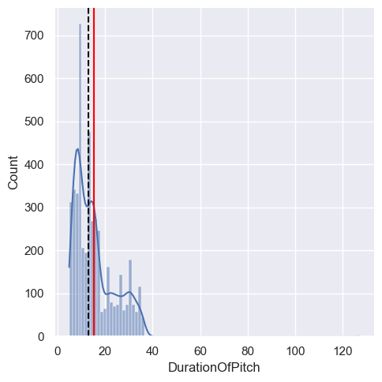

```python
sns.displot(df['DurationOfPitch'], kde = True)
plt.axvline(x = df.DurationOfPitch.median(), color = 'black', ls='--')
plt.axvline(x = df.DurationOfPitch.mean(), color = 'red')
```

##### Observations

This data is extremely skewed right, we will have to come back when we are examining outliers later on and fix this, as I believe the 120 is an inaccurate number, given the KDE near 1 out to 120. We will have to impute with the median rather than the mean for null values. Due to the large number, splitting by whether they purchased or not seems wise again.

##### Finding the Values

```python
ReturnByPurchase('DurationOfPitch')
```

```
Purchased Mean: 16.873143
Purchased Median: 15.0
Purchased Mode: 0    9.0
Name: DurationOfPitch, dtype: float64

-----------

Unpurchased Mean: 15.169325
Unpurchased Median: 13.0
Unpurchased Mode: 0    9.0
Name: DurationOfPitch, dtype: float64
```

##### Setting the Values

```python
df.loc[(df['DurationOfPitch'].isnull() == True) & (df['ProdTaken'] == 1), ['DurationOfPitch']] = 15
df.loc[(df['DurationOfPitch'].isnull() == True) & (df['ProdTaken'] == 0),['DurationOfPitch']] = 13
```

#### Examining Changes

```python
df.DurationOfPitch.describe()
```

```
count    4888.000000
mean       15.381342
std         8.313127
min         5.000000
25%         9.000000
50%        13.000000
75%        19.000000
max       127.000000
Name: DurationOfPitch, dtype: float64
```

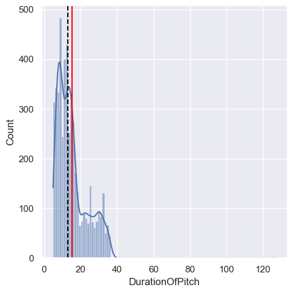

```python
sns.displot(df['DurationOfPitch'], kde = True)
plt.axvline(x = df.DurationOfPitch.median(), color = 'black', ls='--')
plt.axvline(x = df.DurationOfPitch.mean(), color = 'red')
```

There appears to be little difference in the structure of the data after these changes, except the increase in the number of objects in the median

### Number of Followups

```python
df.NumberOfFollowups.isna().sum()
```

```
45
```

```python
df.NumberOfFollowups.describe()
```

```
count    4843.000000
mean        3.708445
std         1.002509
min         1.000000
25%         3.000000
50%         4.000000
75%         4.000000
max         6.000000
Name: NumberOfFollowups, dtype: float64
```

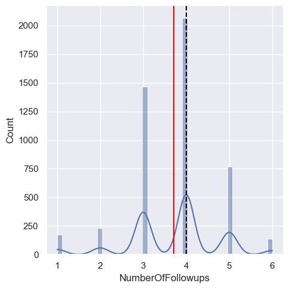

```python
sns.displot(df['NumberOfFollowups'], kde = True)
plt.axvline(x = df.NumberOfFollowups.median(), color = 'black', ls='--')
plt.axvline(x = df.NumberOfFollowups.mean(), color = 'red')
```

##### Observations

This is mainly categorical with an integer, with the median and mode both being 4, and the mean a little off at 3.7. This likely has bearing on the dependent variable, so we will impute with that in mind

##### Finding the Values

```python
ReturnByPurchase('NumberOfFollowups')
```

```
Purchased Mean: 3.941886
Purchased Median: 4.0
Purchased Mode: 0    4.0
Name: NumberOfFollowups, dtype: float64

-----------

Unpurchased Mean: 3.654286
Unpurchased Median: 4.0
Unpurchased Mode: 0    4.0
Name: NumberOfFollowups, dtype: float64
```

##### Setting the Values

```python
df.loc[df['NumberOfFollowups'].isnull(), ['NumberOfFollowups']] = 4
```

#### Checking the Results

```python
df.NumberOfFollowups.isna().sum()
```

```
0
```

```python
df.NumberOfFollowups.describe()
```

```
count    4888.000000
mean        3.711129
std         0.998271
min         1.000000
25%         3.000000
50%         4.000000
75%         4.000000
max         6.000000
Name: NumberOfFollowups, dtype: float64
```

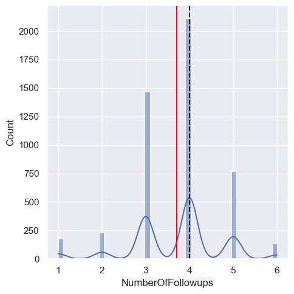

```python
sns.displot(df['NumberOfFollowups'], kde = True)
plt.axvline(x = df.NumberOfFollowups.median(), color = 'black', ls='--')
plt.axvline(x = df.NumberOfFollowups.mean(), color = 'red')
```

The data looks to mostly be in the same shape as before, due to the low number of changes to fields

### Preferred Property Star

```python
df.PreferredPropertyStar.isna().sum()
```

```
26
```

```python
df.PreferredPropertyStar.describe()
```

```
count    4862.000000
mean        3.581037
std         0.798009
min         3.000000
25%         3.000000
50%         3.000000
75%         4.000000
max         5.000000
Name: PreferredPropertyStar, dtype: float64
```

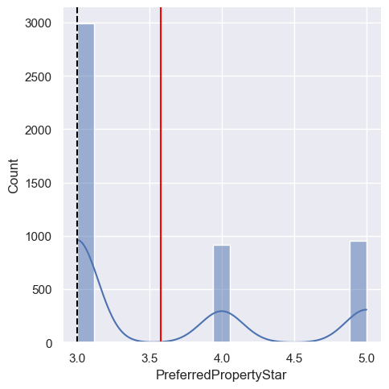

```python
sns.displot(df['PreferredPropertyStar'], kde = True)
plt.axvline(x = df.PreferredPropertyStar.median(), color = 'black', ls='--')
plt.axvline(x = df.PreferredPropertyStar.mean(), color = 'red')
```

##### Observations

This is another categorical value with an integer base. The median and Mode are both at 3, and the mean is a bit above at 3.58 I will impute with the median once more

##### Finding the Values

```python
ReturnByPurchase('PreferredPropertyStar')
```

```
Purchased Mean: 3.746171
Purchased Median: 3.0
Purchased Mode: 0    3.0
Name: PreferredPropertyStar, dtype: float64

-----------

Unpurchased Mean: 3.542806
Unpurchased Median: 3.0
Unpurchased Mode: 0    3.0
Name: PreferredPropertyStar, dtype: float64
```

```python
df.loc[df['PreferredPropertyStar'].isnull(), ['PreferredPropertyStar']] = 3
```

#### Checking the Results

```python
df.PreferredPropertyStar.isna().sum()
```

```
0
```

```python
df.PreferredPropertyStar.describe()
```

```
count    4888.000000
mean        3.577946
std         0.797005
min         3.000000
25%         3.000000
50%         3.000000
75%         4.000000
max         5.000000
Name: PreferredPropertyStar, dtype: float64
```

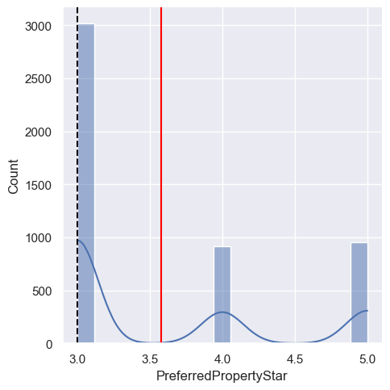

```python
sns.displot(df['PreferredPropertyStar'], kde = True)
plt.axvline(x = df.PreferredPropertyStar.median(), color = 'black', ls='--')
plt.axvline(x = df.PreferredPropertyStar.mean(), color = 'red')
```

As expected at this point, the data appears to mostly be the same as before.

### Number of Trips

```python
df.NumberOfTrips.isna().sum()
```

```
140
```

```python
df.NumberOfTrips.describe()
```

```
count    4748.000000
mean        3.236521
std         1.849019
min         1.000000
25%         2.000000
50%         3.000000
75%         4.000000
max        22.000000
Name: NumberOfTrips, dtype: float64
```

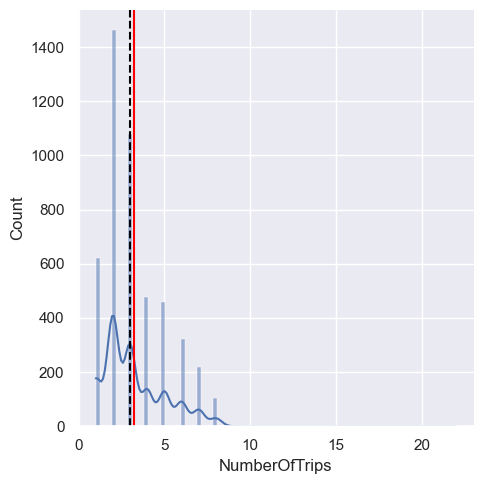

```python
sns.displot(df['NumberOfTrips'], kde = True)
plt.axvline(x = df.NumberOfTrips.median(), color = 'black', ls='--')
plt.axvline(x = df.NumberOfTrips.mean(), color = 'red')
```

##### Observations

The median and mean are close, and there is definitely an outlier up at 22, given the right skew, I will impute our missing values with the Median

##### Finding the Values

```python
ReturnByPurchase('NumberOfTrips')
```

```
Purchased Mean: 3.30837
Purchased Median: 3.0
Purchased Mode: 0    2.0
Name: NumberOfTrips, dtype: float64

-----------

Unpurchased Mean: 3.219531
Unpurchased Median: 3.0
Unpurchased Mode: 0    2.0
Name: NumberOfTrips, dtype: float64
```

##### Changing the Values

```python
df.loc[df['NumberOfTrips'].isnull(), ['NumberOfTrips']] = 3
```

#### Checking the Changes

```python
df.NumberOfTrips.isna().sum()
```

```
0
```

```python
df.NumberOfTrips.describe()
```

```
count    4888.000000
mean        3.229746
std         1.822769
min         1.000000
25%         2.000000
50%         3.000000
75%         4.000000
max        22.000000
Name: NumberOfTrips, dtype: float64
```

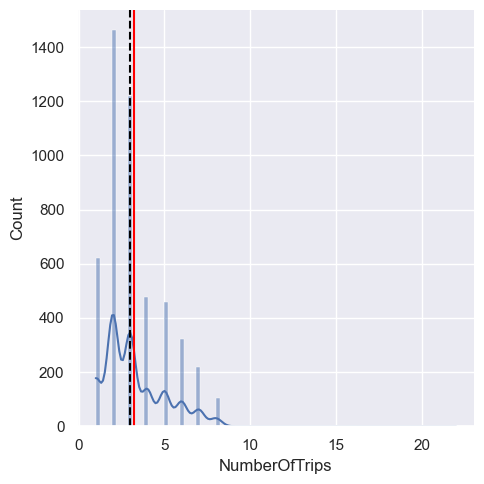

```python
sns.displot(df['NumberOfTrips'], kde = True)
plt.axvline(x = df.NumberOfTrips.median(), color = 'black', ls='--')
plt.axvline(x = df.NumberOfTrips.mean(), color = 'red')
```

At the risk of sounding like a broken record, our data looks similar to how it was initially which we expected

### Number of Children Visitng

```python
df.NumberOfChildrenVisiting.isna().sum()
```

```
66
```

```python
df.NumberOfChildrenVisiting.describe()
```

```
count    4822.000000
mean        1.187267
std         0.857861
min         0.000000
25%         1.000000
50%         1.000000
75%         2.000000
max         3.000000
Name: NumberOfChildrenVisiting, dtype: float64
```

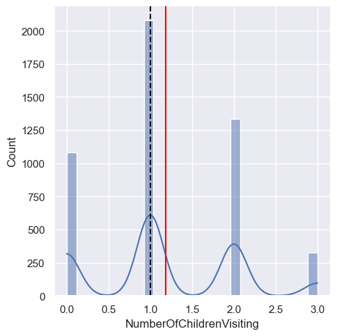

```python
sns.displot(df['NumberOfChildrenVisiting'], kde = True)
plt.axvline(x = df.NumberOfChildrenVisiting.median(), color = 'black', ls='--')
plt.axvline(x = df.NumberOfChildrenVisiting.mean(), color = 'red')
```

##### Observations

The median and mode are equal at one, and the mean is slightly higher at 1.18, we will impute the missing values with the median

##### Finding the Values

```python
ReturnByPurchase('NumberOfChildrenVisiting')
```

```
Purchased Mean: 1.200438
Purchased Median: 1.0
Purchased Mode: 0    1.0
Name: NumberOfChildrenVisiting, dtype: float64

-----------

Unpurchased Mean: 1.18419
Unpurchased Median: 1.0
Unpurchased Mode: 0    1.0
Name: NumberOfChildrenVisiting, dtype: float64
```

##### Changing the Values

```python
df.loc[df['NumberOfChildrenVisiting'].isnull(), ['NumberOfChildrenVisiting']] = 1
```

#### Checking the Changes

```python
df.NumberOfChildrenVisiting.isna().sum()
```

```
0
```

```python
df.NumberOfChildrenVisiting.describe()
```

```
count    4888.000000
mean        1.184738
std         0.852323
min         0.000000
25%         1.000000
50%         1.000000
75%         2.000000
max         3.000000
Name: NumberOfChildrenVisiting, dtype: float64
```

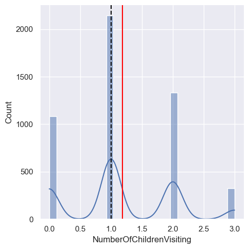

```python
sns.displot(df['NumberOfChildrenVisiting'], kde = True)
plt.axvline(x = df.NumberOfChildrenVisiting.median(), color = 'black', ls='--')
plt.axvline(x = df.NumberOfChildrenVisiting.mean(), color = 'red')
```

The median did not change, and the mean decreased by 0.003, so an insignificant change overall

### Monthly Income

```python
df.MonthlyIncome.isna().sum()
```

```
233
```

```python
df.MonthlyIncome.describe()
```

```
count     4655.000000
mean     23619.853491
std       5380.698361
min       1000.000000
25%      20346.000000
50%      22347.000000
75%      25571.000000
max      98678.000000
Name: MonthlyIncome, dtype: float64
```

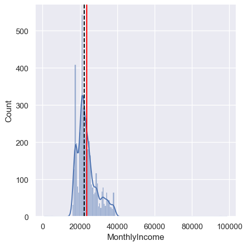

```python
sns.displot(df['MonthlyIncome'], kde = True)
plt.axvline(x = df.MonthlyIncome.median(), color = 'black', ls='--')
plt.axvline(x = df.MonthlyIncome.mean(), color = 'red')
```

##### Observations

We have a few pieces of data causing skewing to the right, with a massive max, as well as some outliers more than likely beneath our dataset. Out median and mean are fairly close in the grand scheme of things, so imputing with median will be helpful in bringing them closer.

##### Finding the Values

```python
ReturnByPurchase('MonthlyIncome')
```

```
Purchased Mean: 22172.827703
Purchased Median: 21172.0
Purchased Mode: 0    17293.0
1    17404.0
2    20971.0
3    21082.0
Name: MonthlyIncome, dtype: float64

-----------

Unpurchased Mean: 23960.962835
Unpurchased Median: 22729.0
Unpurchased Mode: 0    20855.0
Name: MonthlyIncome, dtype: float64
```

##### Changing the Values

```python
df.loc[(df['MonthlyIncome'].isnull() == True) & (df['ProdTaken'] == 1), ['MonthlyIncome']] = 21172
df.loc[(df['MonthlyIncome'].isnull() == True) & (df['ProdTaken'] == 0),['MonthlyIncome']] = 22729
```

#### Checking the Changes

```python
df.MonthlyIncome.isna().sum()
```

```
0
```

```python
df.MonthlyIncome.describe()
```

```
count     4888.000000
mean     23567.195376
std       5257.438805
min       1000.000000
25%      20485.000000
50%      22595.500000
75%      25424.750000
max      98678.000000
Name: MonthlyIncome, dtype: float64
```

[figure not shown]

```python
sns.displot(df['NumberOfTrips'], kde = True)
plt.axvline(x = df.NumberOfTrips.median(), color = 'black', ls='--')
plt.axvline(x = df.NumberOfTrips.mean(), color = 'red')
```

The mean dropped a little bit, and the median increased some, but the overall structure of the data stays mostly unchanged

### Confirming no more Null Values

```python
df.isna().sum()
```

```
ProdTaken                   0
Age                         0
TypeofContact               0
CityTier                    0
DurationOfPitch             0
Occupation                  0
Gender                      0
NumberOfPersonVisiting      0
NumberOfFollowups           0
ProductPitched              0
PreferredPropertyStar       0
MaritalStatus               0
NumberOfTrips               0
Passport                    0
PitchSatisfactionScore      0
OwnCar                      0
NumberOfChildrenVisiting    0
Designation                 0
MonthlyIncome               0
dtype: int64
```

## Handling Outliers

```python
df.describe().T
```

|  | count | mean | std | min | 25% | 50% | 75% | max |
| --- | --- | --- | --- | --- | --- | --- | --- | --- |
| ProdTaken | 4888.0 | 0.188216 | 0.390925 | 0.0 | 0.0 | 0.0 | 0.00 | 1.0 |
| Age | 4888.0 | 37.557488 | 9.109545 | 18.0 | 31.0 | 37.0 | 43.00 | 61.0 |
| CityTier | 4888.0 | 1.654255 | 0.916583 | 1.0 | 1.0 | 1.0 | 3.00 | 3.0 |
| DurationOfPitch | 4888.0 | 15.381342 | 8.313127 | 5.0 | 9.0 | 13.0 | 19.00 | 127.0 |
| NumberOfPersonVisiting | 4888.0 | 2.905074 | 0.724891 | 1.0 | 2.0 | 3.0 | 3.00 | 5.0 |
| NumberOfFollowups | 4888.0 | 3.711129 | 0.998271 | 1.0 | 3.0 | 4.0 | 4.00 | 6.0 |
| PreferredPropertyStar | 4888.0 | 3.577946 | 0.797005 | 3.0 | 3.0 | 3.0 | 4.00 | 5.0 |
| NumberOfTrips | 4888.0 | 3.229746 | 1.822769 | 1.0 | 2.0 | 3.0 | 4.00 | 22.0 |
| Passport | 4888.0 | 0.290917 | 0.454232 | 0.0 | 0.0 | 0.0 | 1.00 | 1.0 |
| PitchSatisfactionScore | 4888.0 | 3.078151 | 1.365792 | 1.0 | 2.0 | 3.0 | 4.00 | 5.0 |
| OwnCar | 4888.0 | 0.620295 | 0.485363 | 0.0 | 0.0 | 1.0 | 1.00 | 1.0 |
| NumberOfChildrenVisiting | 4888.0 | 1.184738 | 0.852323 | 0.0 | 1.0 | 1.0 | 2.00 | 3.0 |
| MonthlyIncome | 4888.0 | 23567.195376 | 5257.438805 | 1000.0 | 20485.0 | 22595.5 | 25424.75 | 98678.0 |

### Duration of Pitch

```python
df.DurationOfPitch.describe()
```

```
count    4888.000000
mean       15.381342
std         8.313127
min         5.000000
25%         9.000000
50%        13.000000
75%        19.000000
max       127.000000
Name: DurationOfPitch, dtype: float64
```

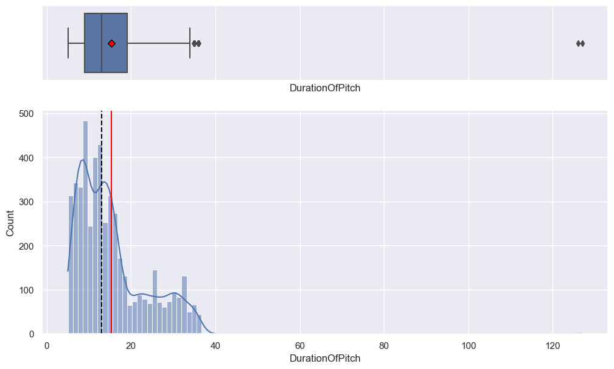

```python
histogramboxplot(data = df, feature = 'DurationOfPitch')
```

There are some pretty extreme outliers in Duration of Pitch, so cleaning up these outliers will really affect the way this data is structured, and hopefully produce better results. The ones close to the whisker are likely accurate, but the ones at 120 minutes seem like erronous entry, so I will set it to the median.

```python
# df[df['DurationOfPitch'] > 120]
```

|  | ProdTaken | Age | TypeofContact | CityTier | DurationOfPitch | Occupation | Gender | NumberOfPersonVisiting | NumberOfFollowups | ProductPitched | PreferredPropertyStar | MaritalStatus | NumberOfTrips | Passport | PitchSatisfactionScore | OwnCar | NumberOfChildrenVisiting | Designation | MonthlyIncome |
| --- | --- | --- | --- | --- | --- | --- | --- | --- | --- | --- | --- | --- | --- | --- | --- | --- | --- | --- | --- |
| 1434 | 0 | 37.0 | Company Invited | 3 | 126.0 | Salaried | Male | 2 | 3.0 | Basic | 3.0 | Married | 3.0 | 0 | 1 | 1 | 1.0 | Executive | 18482.0 |
| 3878 | 0 | 53.0 | Company Invited | 3 | 127.0 | Salaried | Male | 3 | 4.0 | Basic | 3.0 | Married | 4.0 | 0 | 1 | 1 | 2.0 | Executive | 22160.0 |

```python
df.groupby("ProdTaken")["DurationOfPitch"].median()
```

```
ProdTaken
0    13.0
1    15.0
Name: DurationOfPitch, dtype: float64
```

```python
df.loc[df['DurationOfPitch'] > 125, 'DurationOfPitch'] = 13
```

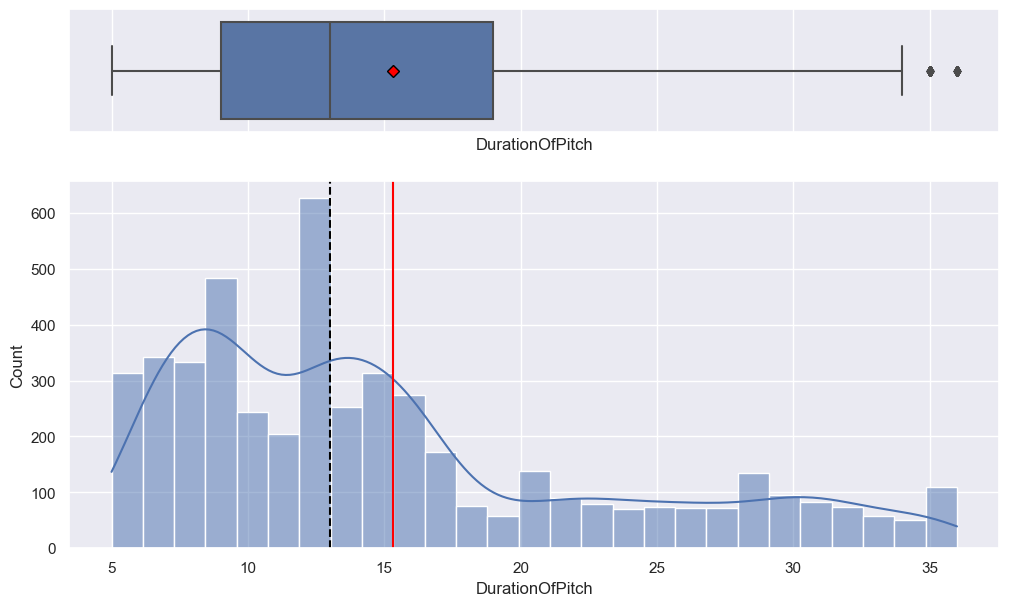

```python
histogramboxplot(data = df, feature = 'DurationOfPitch')
```

This has improved the look of the dataset immediately, and makes it more approachable for further modification if needed, but ultimately likely will not

### Number of Persons Visiting

```python
df.DurationOfPitch.describe()
```

[output not shown]

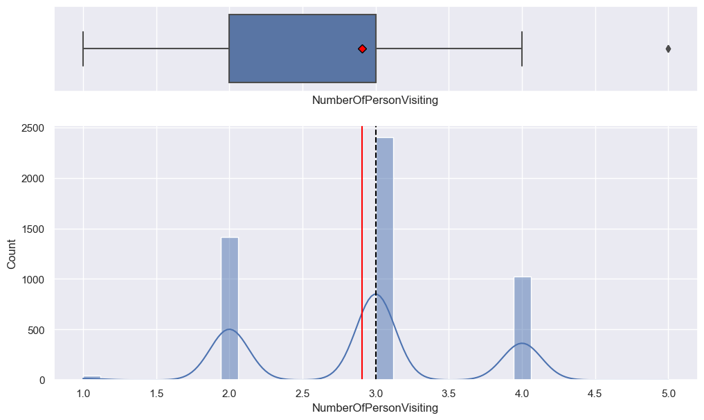

```python
histogramboxplot(data = df, feature = 'NumberOfPersonVisiting')
```

This only has one outlier at the top, and it feels like it is likely an accurate value, so I will be leaving it for the time being

### Number of Followups

```python
df.DurationOfPitch.describe()
```

[output not shown]

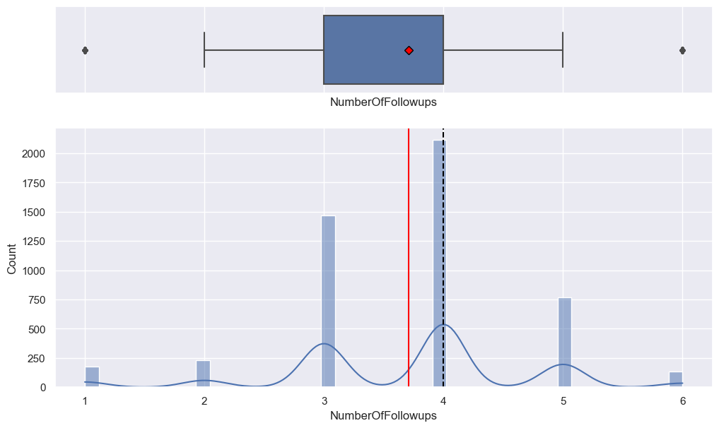

```python
histogramboxplot(data = df, feature = 'NumberOfFollowups')
```

### Number of Trips

```python
df.DurationOfPitch.describe()
```

[output not shown]

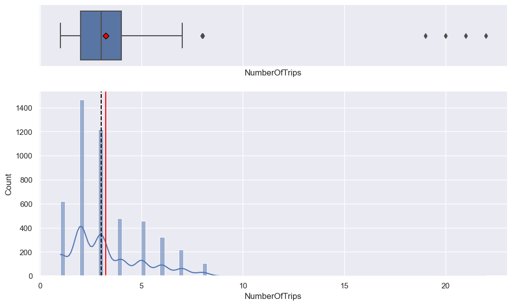

```python
histogramboxplot(data = df, feature = 'NumberOfTrips')
```

This one was a debate, it is possible that the outliers at the top were accurate, but they also seem a bit extreme for the dataset, and may throw off a model. I have decided to take the values that are above 15 and impute them with the median, but leave the one near ten

```python
# df[df['NumberOfTrips'] > 15]
```

|  | ProdTaken | Age | TypeofContact | CityTier | DurationOfPitch | Occupation | Gender | NumberOfPersonVisiting | NumberOfFollowups | ProductPitched | PreferredPropertyStar | MaritalStatus | NumberOfTrips | Passport | PitchSatisfactionScore | OwnCar | NumberOfChildrenVisiting | Designation | MonthlyIncome |
| --- | --- | --- | --- | --- | --- | --- | --- | --- | --- | --- | --- | --- | --- | --- | --- | --- | --- | --- | --- |
| 385 | 1 | 30.0 | Company Invited | 1 | 10.0 | Large Business | Male | 2 | 3.0 | Basic | 3.0 | Single | 19.0 | 1 | 4 | 1 | 1.0 | Executive | 17285.0 |
| 816 | 0 | 39.0 | Company Invited | 1 | 15.0 | Salaried | Male | 3 | 3.0 | Deluxe | 4.0 | Unmarried | 21.0 | 0 | 2 | 1 | 0.0 | Manager | 21782.0 |
| 2829 | 1 | 31.0 | Company Invited | 1 | 11.0 | Large Business | Male | 3 | 4.0 | Basic | 3.0 | Single | 20.0 | 1 | 4 | 1 | 2.0 | Executive | 20963.0 |
| 3260 | 0 | 40.0 | Company Invited | 1 | 16.0 | Salaried | Male | 4 | 4.0 | Deluxe | 4.0 | Unmarried | 22.0 | 0 | 2 | 1 | 1.0 | Manager | 25460.0 |

```python
df.groupby("ProdTaken")["NumberOfTrips"].median()
```

```
ProdTaken
0    3.0
1    3.0
Name: NumberOfTrips, dtype: float64
```

```python
df.loc[df['NumberOfTrips'] > 18, 'NumberOfTrips'] = 3
```

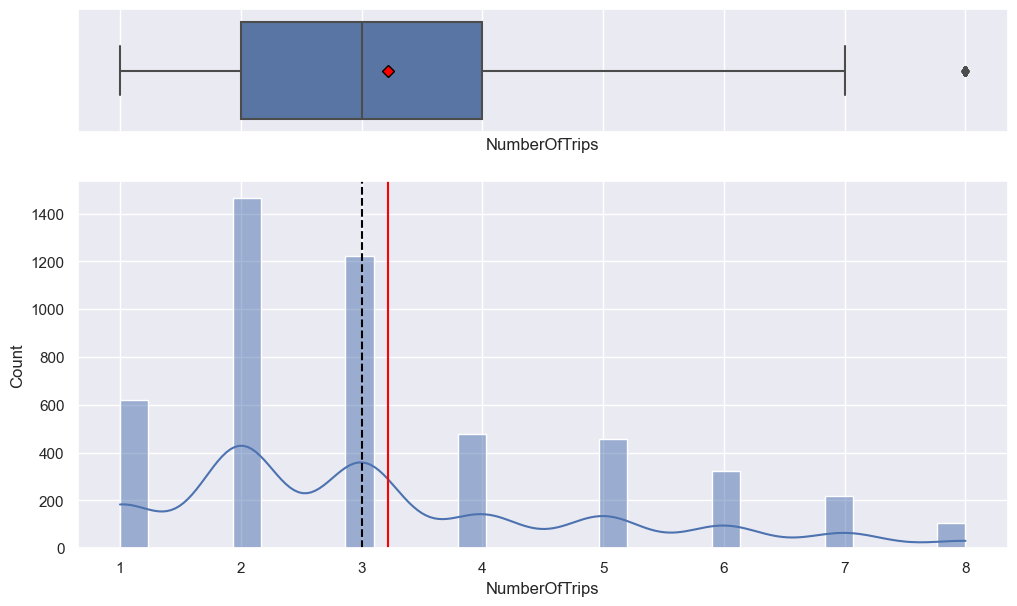

```python
histogramboxplot(data = df, feature = 'NumberOfTrips')
```

This seems to keep the shape of the data well intact, while leaving a likely accurate outlier in the data to prevent model overfit

### Monthly Income

```python
df.DurationOfPitch.describe()
```

[output not shown]

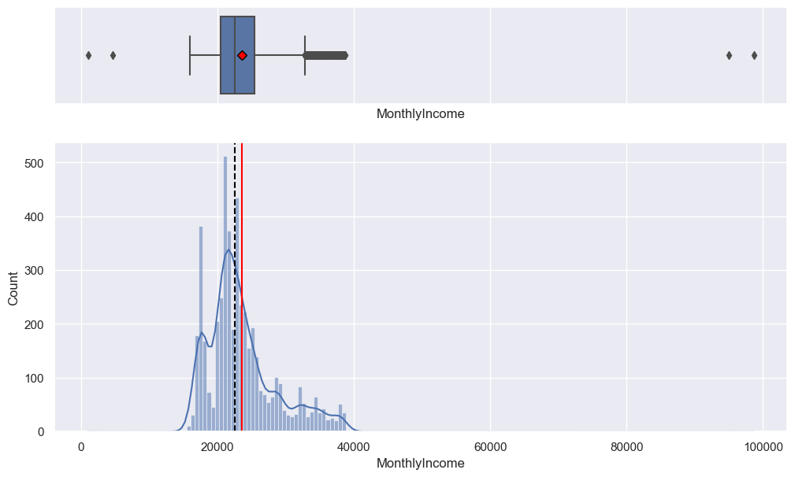

```python
histogramboxplot(data = df, feature = 'MonthlyIncome')
```

There are some outliers low, and a ton of outliers high. The ones below 40,000 seem likely accurate, but the ones approaching 100,000 a month seem likely erronous. I will examine the low values, determine if their data seems erronous, and then decide how to impute them. I will leave the values below 40,000 intact and impute the ones above 80,000 with the median

```python
# df[df['MonthlyIncome'] < 10000]
```

|  | ProdTaken | Age | TypeofContact | CityTier | DurationOfPitch | Occupation | Gender | NumberOfPersonVisiting | NumberOfFollowups | ProductPitched | PreferredPropertyStar | MaritalStatus | NumberOfTrips | Passport | PitchSatisfactionScore | OwnCar | NumberOfChildrenVisiting | Designation | MonthlyIncome |
| --- | --- | --- | --- | --- | --- | --- | --- | --- | --- | --- | --- | --- | --- | --- | --- | --- | --- | --- | --- |
| 142 | 0 | 38.0 | Self Enquiry | 1 | 9.0 | Large Business | Female | 2 | 3.0 | Deluxe | 3.0 | Single | 4.0 | 1 | 5 | 0 | 0.0 | Manager | 1000.0 |
| 2586 | 0 | 39.0 | Self Enquiry | 1 | 10.0 | Large Business | Female | 3 | 4.0 | Deluxe | 3.0 | Single | 5.0 | 1 | 5 | 0 | 1.0 | Manager | 4678.0 |

These values seem inaccurate given the fact that they are living in a major city, and are a manager in large busines. I will impute them with the median

```python
# df[df['MonthlyIncome'] > 80000]
```

|  | ProdTaken | Age | TypeofContact | CityTier | DurationOfPitch | Occupation | Gender | NumberOfPersonVisiting | NumberOfFollowups | ProductPitched | PreferredPropertyStar | MaritalStatus | NumberOfTrips | Passport | PitchSatisfactionScore | OwnCar | NumberOfChildrenVisiting | Designation | MonthlyIncome |
| --- | --- | --- | --- | --- | --- | --- | --- | --- | --- | --- | --- | --- | --- | --- | --- | --- | --- | --- | --- |
| 38 | 0 | 36.0 | Self Enquiry | 1 | 11.0 | Salaried | Female | 2 | 4.0 | Basic | 3.0 | Divorced | 1.0 | 1 | 2 | 1 | 0.0 | Executive | 95000.0 |
| 2482 | 0 | 37.0 | Self Enquiry | 1 | 12.0 | Salaried | Female | 3 | 5.0 | Basic | 5.0 | Divorced | 2.0 | 1 | 2 | 1 | 1.0 | Executive | 98678.0 |

```python
df.groupby("ProdTaken")["MonthlyIncome"].median()
```

```
ProdTaken
0    22729.0
1    21172.0
Name: MonthlyIncome, dtype: float64
```

```python
df.loc[df['MonthlyIncome'] > 80000, 'MonthlyIncome'] = 22729
df.loc[df['MonthlyIncome'] < 10000, 'MonthlyIncome'] = 22729
```

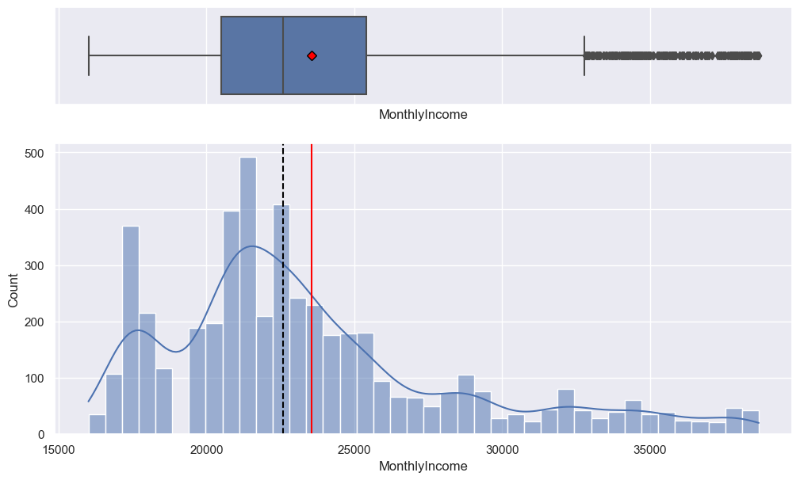

```python
histogramboxplot(data = df, feature = 'MonthlyIncome')
```

This seems much better in terms of data, I will likely log scale this later due to the high number just outside the the upper whisker, but for now, I will leave it be.

### Remove erronous Categorical Data

```python
df['Gender'].value_counts()
```

```
Male       2916
Female     1817
Fe Male     155
Name: Gender, dtype: int64
```

```python
df.loc[df['Gender'] == 'Fe Male', ['Gender']] = 'Female'
```

```python
df['Gender'].value_counts()
```

```
Male      2916
Female    1972
Name: Gender, dtype: int64
```

# Exploratory Data Analysis

## Univariate Analysis

```python
# df.head(5)
```

|  | ProdTaken | Age | TypeofContact | CityTier | DurationOfPitch | Occupation | Gender | NumberOfPersonVisiting | NumberOfFollowups | ProductPitched | PreferredPropertyStar | MaritalStatus | NumberOfTrips | Passport | PitchSatisfactionScore | OwnCar | NumberOfChildrenVisiting | Designation | MonthlyIncome |
| --- | --- | --- | --- | --- | --- | --- | --- | --- | --- | --- | --- | --- | --- | --- | --- | --- | --- | --- | --- |
| 0 | 1 | 41.0 | Self Enquiry | 3 | 6.0 | Salaried | Female | 3 | 3.0 | Deluxe | 3.0 | Single | 1.0 | 1 | 2 | 1 | 0.0 | Manager | 20993.0 |
| 1 | 0 | 49.0 | Company Invited | 1 | 14.0 | Salaried | Male | 3 | 4.0 | Deluxe | 4.0 | Divorced | 2.0 | 0 | 3 | 1 | 2.0 | Manager | 20130.0 |
| 2 | 1 | 37.0 | Self Enquiry | 1 | 8.0 | Free Lancer | Male | 3 | 4.0 | Basic | 3.0 | Single | 7.0 | 1 | 3 | 0 | 0.0 | Executive | 17090.0 |
| 3 | 0 | 33.0 | Company Invited | 1 | 9.0 | Salaried | Female | 2 | 3.0 | Basic | 3.0 | Divorced | 2.0 | 1 | 5 | 1 | 1.0 | Executive | 17909.0 |
| 4 | 0 | 37.0 | Self Enquiry | 1 | 8.0 | Small Business | Male | 2 | 3.0 | Basic | 4.0 | Divorced | 1.0 | 0 | 5 | 1 | 0.0 | Executive | 18468.0 |

```python
df.describe().T
```

|  | count | mean | std | min | 25% | 50% | 75% | max |
| --- | --- | --- | --- | --- | --- | --- | --- | --- |
| ProdTaken | 4888.0 | 0.188216 | 0.390925 | 0.0 | 0.00 | 0.0 | 0.00 | 1.0 |
| Age | 4888.0 | 37.557488 | 9.109545 | 18.0 | 31.00 | 37.0 | 43.00 | 61.0 |
| CityTier | 4888.0 | 1.654255 | 0.916583 | 1.0 | 1.00 | 1.0 | 3.00 | 3.0 |
| DurationOfPitch | 4888.0 | 15.334902 | 8.003437 | 5.0 | 9.00 | 13.0 | 19.00 | 36.0 |
| NumberOfPersonVisiting | 4888.0 | 2.905074 | 0.724891 | 1.0 | 2.00 | 3.0 | 3.00 | 5.0 |
| NumberOfFollowups | 4888.0 | 3.711129 | 0.998271 | 1.0 | 3.00 | 4.0 | 4.00 | 6.0 |
| PreferredPropertyStar | 4888.0 | 3.577946 | 0.797005 | 3.0 | 3.00 | 3.0 | 4.00 | 5.0 |
| NumberOfTrips | 4888.0 | 3.215426 | 1.754188 | 1.0 | 2.00 | 3.0 | 4.00 | 8.0 |
| Passport | 4888.0 | 0.290917 | 0.454232 | 0.0 | 0.00 | 0.0 | 1.00 | 1.0 |
| PitchSatisfactionScore | 4888.0 | 3.078151 | 1.365792 | 1.0 | 2.00 | 3.0 | 4.00 | 5.0 |
| OwnCar | 4888.0 | 0.620295 | 0.485363 | 0.0 | 0.00 | 1.0 | 1.00 | 1.0 |
| NumberOfChildrenVisiting | 4888.0 | 1.184738 | 0.852323 | 0.0 | 1.00 | 1.0 | 2.00 | 3.0 |
| MonthlyIncome | 4888.0 | 23545.010434 | 5026.428314 | 16009.0 | 20486.75 | 22596.5 | 25407.75 | 38677.0 |

### Age

```
count    4888.000000
mean       37.557488
std         9.109545
min        18.000000
25%        31.000000
50%        37.000000
75%        43.000000
max        61.000000
Name: Age, dtype: float64
```

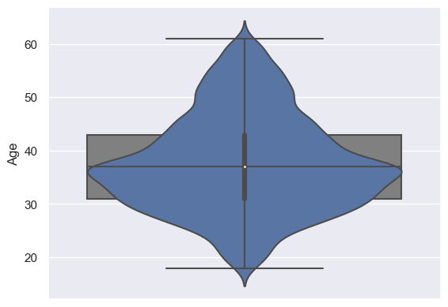

```python
descviolinbox(df, 'Age')
```

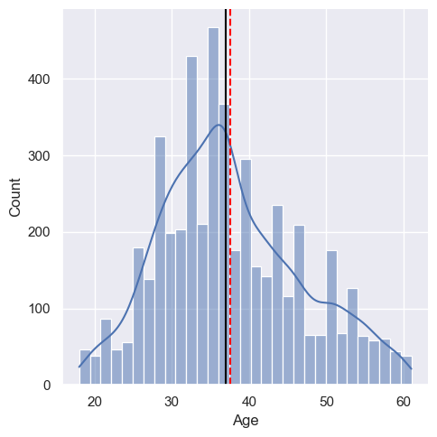

```python
labeldisplot(df, 'Age')
```

```python
bounds(df, 'Age')
```

```
Q1: 31.0
Q3: 43.0
IQR: 12.0
lower limit: 13.0
upper limit: 61.0
```

```
(13.0, 61.0, 31.0, 43.0)
```

```python
numericdata(df, 'Age')
```

```
Mean: 37.557488
Median: 37.0
Mode: 37.0
Range: 12.0
```

##### Observations

Mean is 37.5 median is 37, mode is *also* 37 and the IQR is 12

- Median and mean are close, with the mean slightly to the right
- There is a slight right skew to the data, but not enough to fix with a log scale down the road
- We will probably want to scale our data, given that it has higher values than most of our data
- Interesting thing that might require looking at the dataset, some ages have double the count to those next to them, not something normally anticipated with age.

### Duration of Pitch

```
count    4888.000000
mean       15.334902
std         8.003437
min         5.000000
25%         9.000000
50%        13.000000
75%        19.000000
max        36.000000
Name: DurationOfPitch, dtype: float64
```

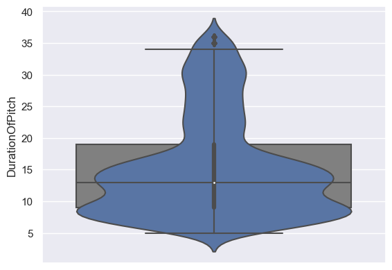

```python
descviolinbox(df, 'DurationOfPitch')
```

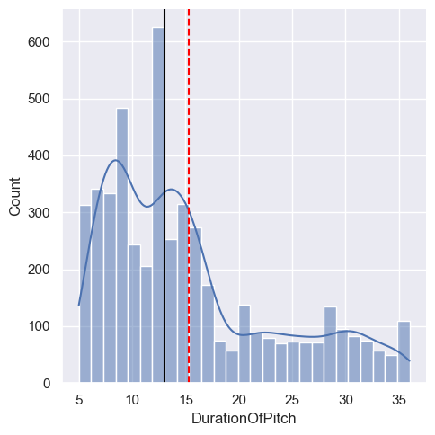

```python
labeldisplot(df, 'DurationOfPitch')
```

```python
bounds(df, 'DurationOfPitch')
```

```
Q1: 9.0
Q3: 19.0
IQR: 10.0
lower limit: -6.0
upper limit: 34.0
```

```
(-6.0, 34.0, 9.0, 19.0)
```

```python
numericdata(df, 'DurationOfPitch')
```

```
Mean: 15.334902
Median: 13.0
Mode: 9.0
Range: 10.0
```

##### Observations

Mean is 15.3, Median is 13, Mode is 9, and the IQR is 10

- We have a pretty significant right skew in our data
- The KDE is important in this graph, because our initial thought was the Mode was 13
- Due to the long right tail, a log scale might be a good idea
- We also may want to just bin the data, as keeping this numeric might overfit the model

### Monthly Income

```
count     4888.000000
mean     23545.010434
std       5026.428314
min      16009.000000
25%      20486.750000
50%      22596.500000
75%      25407.750000
max      38677.000000
Name: MonthlyIncome, dtype: float64
```

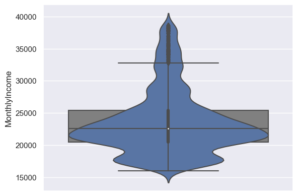

```python
descviolinbox(df, 'MonthlyIncome')
```

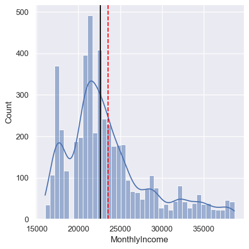

```python
labeldisplot(df, 'MonthlyIncome')
```

```python
bounds(df, 'MonthlyIncome')
```

```
Q1: 20486.75
Q3: 25407.75
IQR: 4921.0
lower limit: 13105.25
upper limit: 32789.25
```

```
(13105.25, 32789.25, 20486.75, 25407.75)
```

```python
numericdata(df, 'MonthlyIncome')
```

```
Mean: 23545.010434
Median: 22596.5
Mode: 22729.0
Range: 4921.0
```

##### Observations

Mean is \$23,545, Median is \$22,597, Mode is \$22,729 and the range is \$4,921

- This data has an extremely long right tale, and correspondingly a significant right skew
- The data is not very close to a normal distribution
- most of the right tail is flat, meaning there are roughly the same number of records
- There is a gap just below 20,000 which doesn't seem like accurate data, acquiring information for customers in this range may help us fit our model
- This seems to be a prime candidate for a log scale, as it has a long right tail, and the numeric values are significantly larger than the rest of the dataset